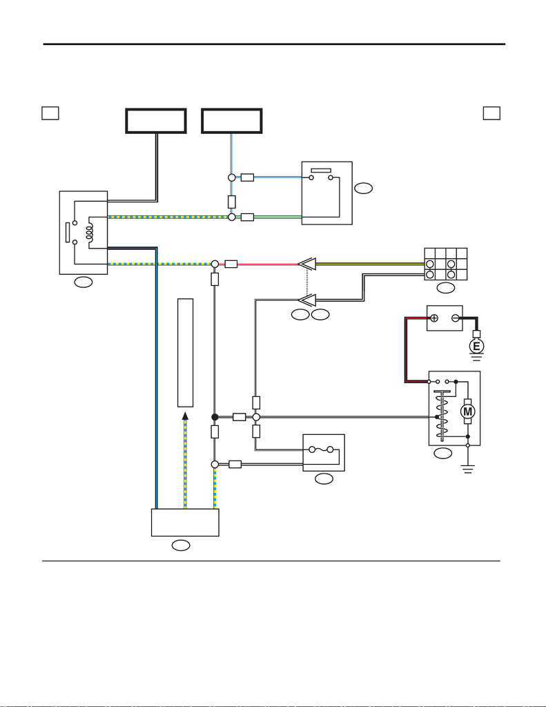

WI-389

Starter System

WIRING SYSTEM

52.Starter System

A: WIRING DIAGRAM

1. ENGINE TYPE FA (WITHOUT PUSH BUTTON START)

ECM

FUSE HOLDER

WI-44579

1a 1a

12

11

B134

B550

A:

CVT

T7

B12 T3

B225

B14

MT

PRND

B106

CVT

MT

MT

B/L

A33

A14

B/W

W/LW/L

B/W

2

3

1

5

CVTCVT

CVT

W/B B/W

W/R

B/W 9

B/Y 6

MT

W/BW/BW/B

BB/R

B/R

A8

4 W/B

MT

W/B

B/W 21

W/B 7

B/L

1

2

3

B/Y

1

LG

2

W/L

1

ST-2

IG SW

(ST)

2

1

3

CLUTCH START

SWITCH

: MT MODEL : G/B

CVT MODEL : R/W

: MT MODEL : LG

CVT MODEL : W/L

4

: MT MODEL : W/B

CVT MODEL : B/W

: MT MODEL : W/B

CVT MODEL : W/R

REF. TO ENGINE ELECTRICAL SYSTEM

[1e]

STARTER MOTOR

INHIBITOR

SWITCH

BATTERY

STARTER RELAY 1

ST-1

F/B FUSE NO. 21

(ST)

10A

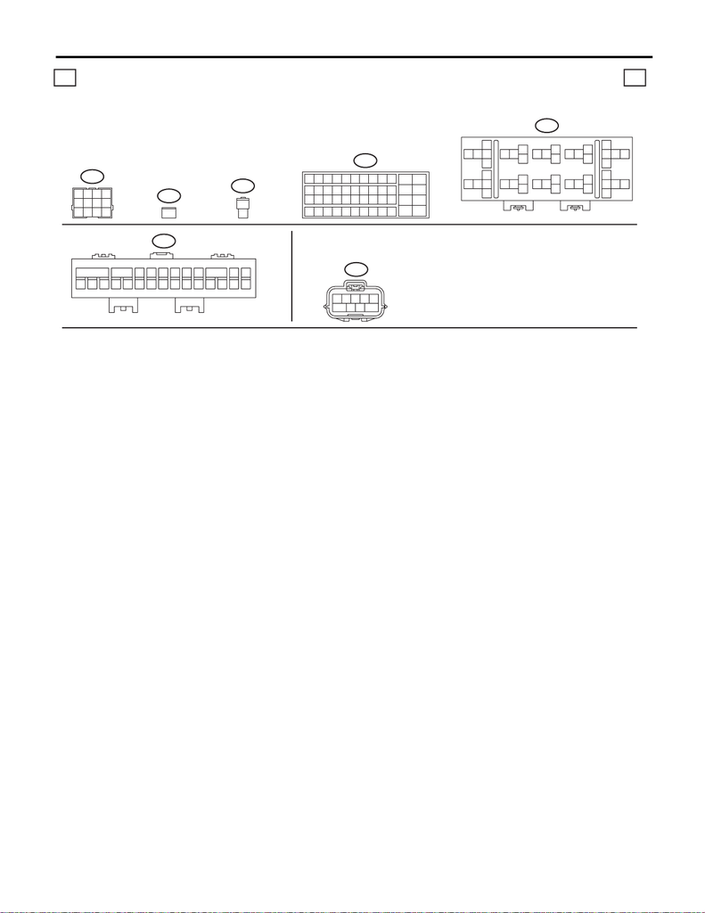

WI-390

Starter System

WIRING SYSTEM

WI-44580

1b 1b

(B)

B12

5

9

1

6

10

2

7

11

3

8

12

4

(B)

B14

1

B106

2

1

B225

10 11

12

13

14 15

16

18

19 21 22

20

17

24

5

3

17

9

8

6

32 33

34

35

28262423

25

27

29

30

31

36 37

38

40

41 43 44

42

39

(B)

T7

1

78

69

2345

91

2

232221 262524201918

4

13

12

17

3

16

6

15

587

14

10 11

B550

(B)

10

11 12

23 24

35 36

47 48

3

5

6

7894

12

45

4643 4441 4239 4037 38

21

2219 2017 1815 1613 14

33

3431 3229 3027 2825 26

(BR)

B134

A:

LIST OF CONNECTORS

RELAY HOLDER

FUSE HOLDER

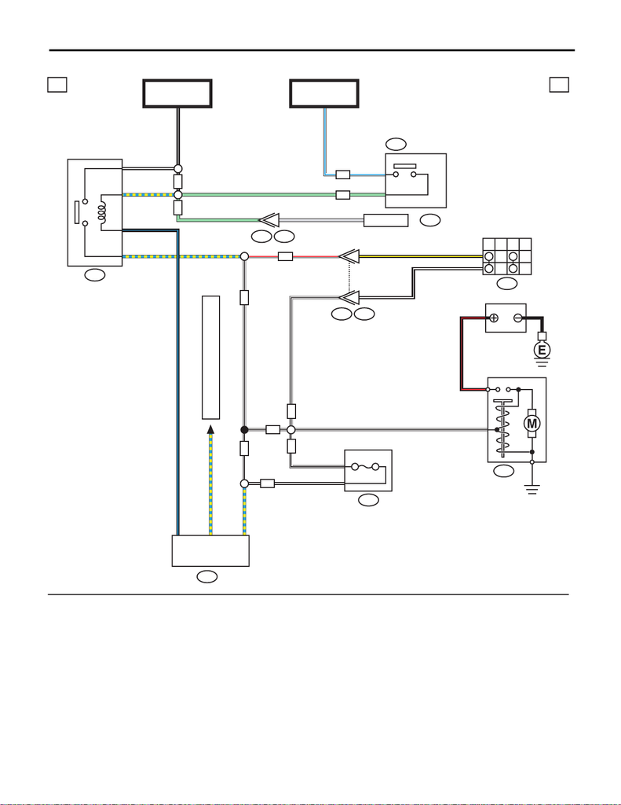

WI-391

Starter System

WIRING SYSTEM

2. ENGINE TYPE FA (WITH PUSH BUTTON START)

WI-44581

2a 2a

12

11

B134A:

T7

B12 T3

B225

B14

PRND

B/L

A14

B/W

W/L

B/W

2

1

2

3LG

1

5

W/B B/W

1

B575 B576

LG GR

W/R

B/W 9

B/Y 6

W/B

B/R

B/R B

W/BW/B

A8

B/L

B/Y

1

ECM

1

2

3

4

B106

3

1

4

MT

CVT

CVT

MT

MT

MT

MT

A33

CVT

MT

W/B

W/B

2

B572A:

A10

KEYLESS

ACCESS CM

FUSE HOLDER

B550

CVT

CVT

B/W 21

W/B 7

STARTER MOTOR

INHIBITOR

SWITCH

BATTERY

STARTER RELAY 1

ST-2

STARTER

CUT RELAY

ST-1

F/B FUSE NO.21

(ST)

: MT MODEL : G/B

CVT MODEL : R/W

: MT MODEL : LG

: MT MODEL : W/B

CVT MODEL : B/W

: MT MODEL : W/B

CVT MODEL : W/R

CLUTCH START

SWITCH

REF. TO ENGINE ELECTRICAL SYSTEM

[2e]

10A

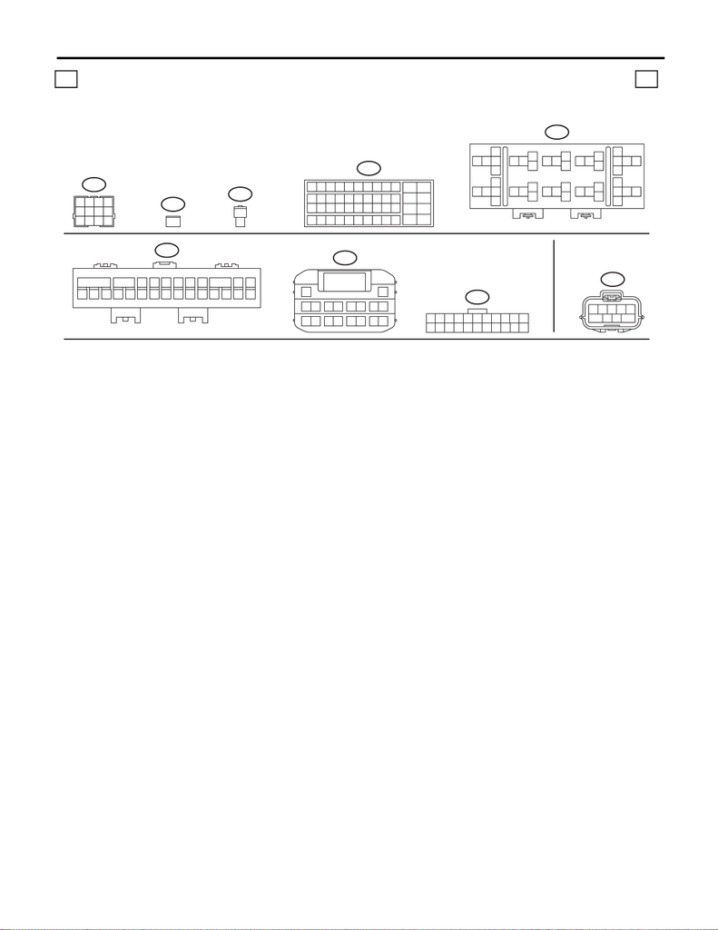

WI-392

Starter System

WIRING SYSTEM

WI-44582

2b 2b

(B)

B12

5

9

1

6

10

2

7

11

3

8

12

4

(B)

B14

1

B225

10 11

12

13

14 15

16

18

19 21 22

20

17

24

5

3

17

9

8

6

32 33

34

35

28262423

25

27

29

30

31

36 37

38

40

41 43 44

42

39

(B)

T7

1

78

69

2345

10

11 12

23 24

35 36

47 48

3

5

6

7894

12

45

4643 4441 4239 4037 38

21

2219 2017 1815 1613 14

33

3431 3229 3027 2825 26

(BR)

B134

A:

123

456789

10 11

12 13 14 15 16 17 18 19 20 21 22

B575

11 12

34

13 14

56

15 16

78

17 18

10

9

12

B572A:

B106

2

1

91

2

232221 262524201918

4

13

12

17

3

16

6

15

587

14

10 11

B550

(B)

LIST OF CONNECTORS

RELAY HOLDER

FUSE HOLDER

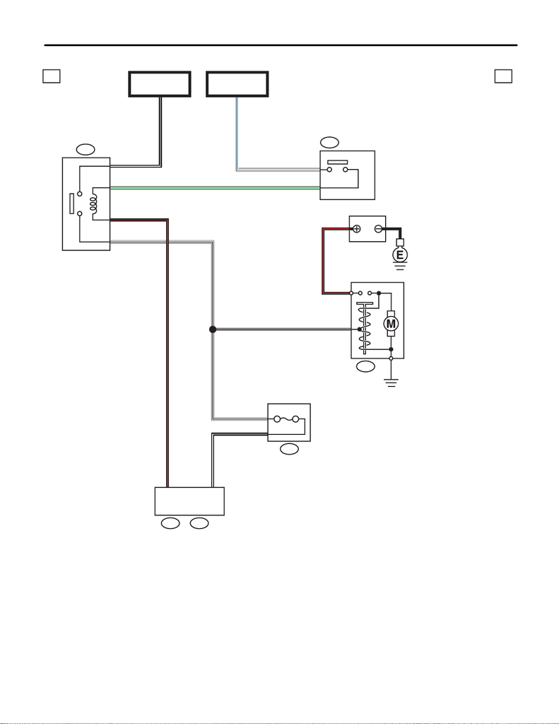

WI-393

Starter System

WIRING SYSTEM

3. ENGINE TYPE EJ (WITHOUT PUSH BUTTON START)

WI-44583

3a 3a

B136C:B135B:

B225

B14

B/R

B26

LG LG

2 B/W

3

5

1 W/B

W/B

B/R

B/R B

C16 B/W W/B

B/R

1

B/W

W/L

ST-2

IG SW

(ST)

ECM

1W/L

2

B106

B/W 22

W/B 8

FUSE HOLDER

B550

ST-1

F/B FUSE NO. 21

(ST)

STARTER MOTOR

BATTERY

STARTER RELAY 1

CLUTCH START

SWITCH

10A

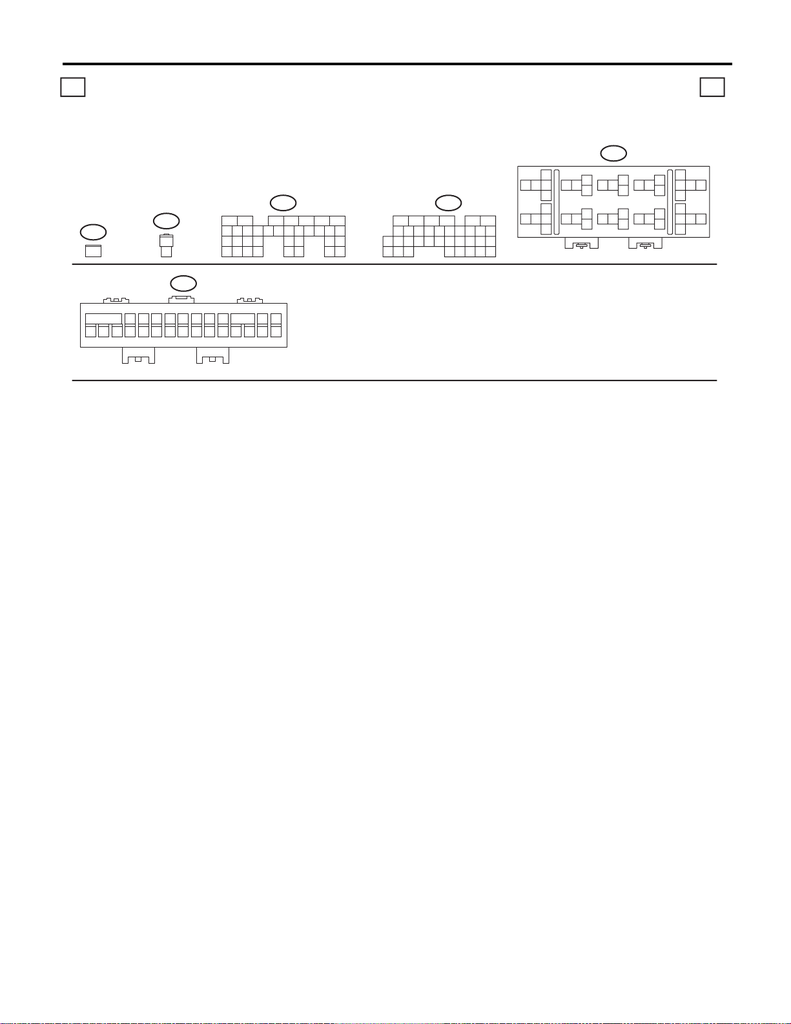

WI-394

Starter System

WIRING SYSTEM

101

242322 272625212019

5

14

13

18

432

17

7

16

698

15

11 12

B550

(B)

WI-44584

3b 3b

(B)

B14

1

B225

10 11

12

13

14 15

16

18

19 21 22

20

17

24

5

3

17

9

8

6

32 33

34

35

28262423

25

27

29

30

31

36 37

38

40

41 43 44

42

39

B106

2

1

B135B:

5672134

29

10 11 12 13 14 15

2524

16

30

98

17 18 19

20

28

21 22 23

3231

26 27

33 34 35

B136C:

19

18

21

20

2322 24 25 26

17

1

23

4

56

27

28 29 30

31 32 33 34 35

798

151413121110 16

FUSE HOLDER

LIST OF CONNECTORS

RELAY HOLDER

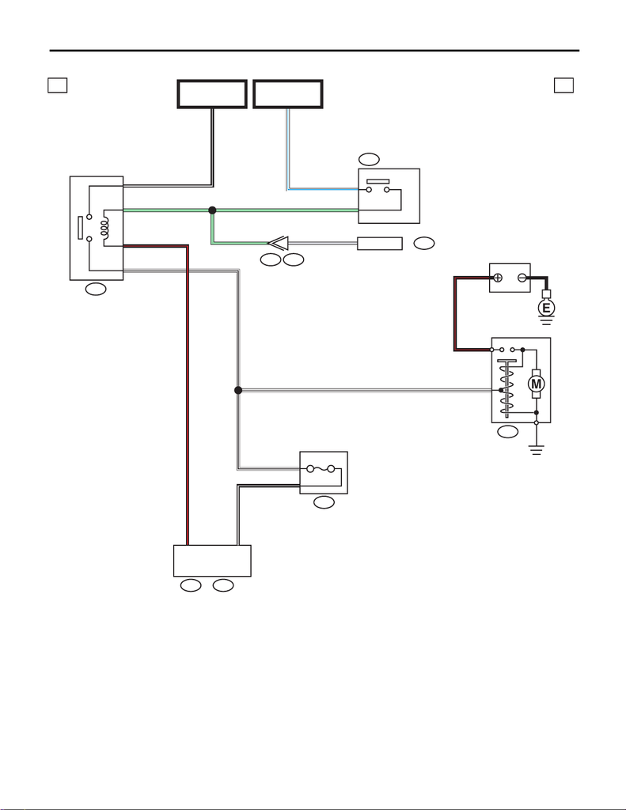

WI-395

Starter System

WIRING SYSTEM

4. ENGINE TYPE EJ (WITH PUSH BUTTON START)

WI-44585

4a 4a

B225

B14

B/R

B26

W/L

B/W

LG LG

W/L

2 B/W

3

5

1 W/B

W/B

B/R

B/R B

C27 B/W

B/R

1

B136C:B135B:

ECM

1

2

B106

W/B

1

B575 B576

LG GR

B572A:

A10

KEYLESS

ACCESS CM

B/W 22

W/B 8

FUSE HOLDER

B550

STARTER MOTOR

BATTERY

STARTER RELAY 1

ST-1

F/B FUSE NO.21

(ST)

ST-2

STARTER

CUT RELAY

CLUTCH START

SWITCH

10A

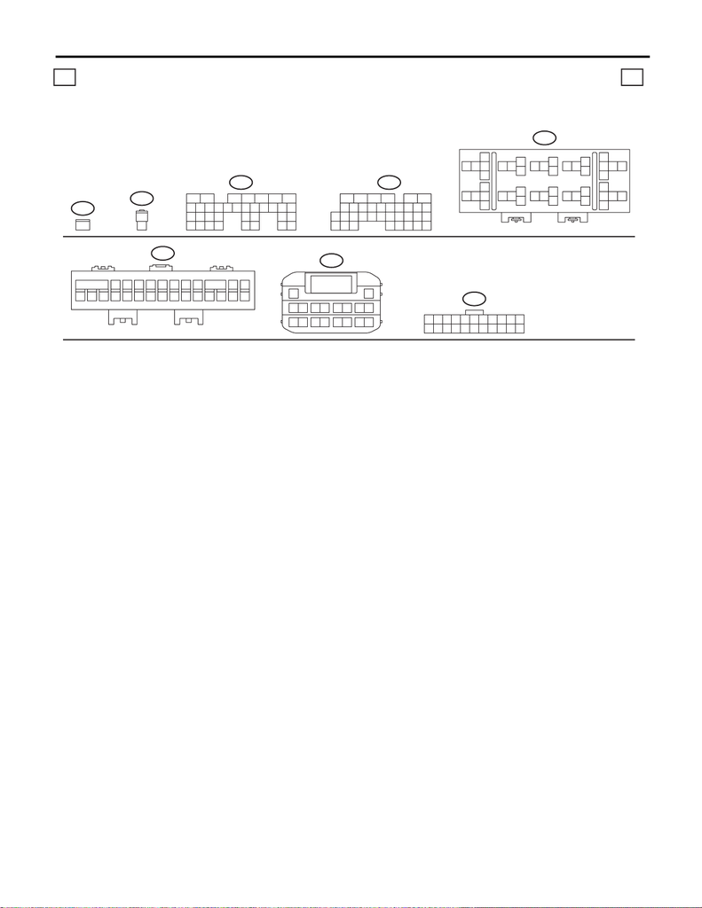

WI-396

Starter System

WIRING SYSTEM

WI-44586

4b 4b

(B)

B14

1

B225

10 11

12

13

14 15

16

18

19 21 22

20

17

24

5

3

17

9

8

6

32 33

34

35

28262423

25

27

29

30

31

36 37

38

40

41 43 44

42

39

B135B:

5672134

29

10 11 12 13 14 15

2524

16

30

98

17 18 19

20

28

21 22 23

3231

26 27

33 34 35

B136C:

19

18

21

20

2322 24 25 26

17

1

23

4

56

27

28 29 30

31 32 33 34 35

798

151413121110 16

101

242322 272625212019

5

14

13

18

432

17

7

16

698

15

11 12

B550

(B)

123

456789

10 11

12 13 14 15 16 17 18 19 20 21 22

B575

11 12

34

13 14

56

15 16

78

17 18

10

9

12

B572A:

B106

2

1

LIST OF CONNECTORS

RELAY HOLDER

FUSE HOLDER